# Ritualized Hostility

## 1.Setup

### 1.1 Packages

I use the `R` Packages below for data management.

```r
library(tidyverse)
library(forcats)
library(lubridate)
```

### 1.2 CAMEO Coding Scheme

To translate CAMEO coding scheme into four more general categories, I rely on the mapping below for recoding.

```r
# Coding Scheme
neutral <- c("010","011","012","013","014","015","016","017","018","019","020",
             "022","023","025","026","027",
             "211", "212", "213", "214", "231", "233","234", "241","242","243",
             "251", "252", "253", "256")
ver_coop <- c("030", "031", "032", "033", "035", "036", "037", "038", "039",
              "040", "041", "042", "043", "044", "045", "046", "050", "051",
              "052", "053", "054", "055", "056", "057",
              "311", "312", "313", "314", "331", "0331", "333", "341", "342", "353")
mat_coop <- c("060", "061", "062","063", "064", "070", "071", "072", "073",
              "074", "075", "080", "081",
              "811", "831", "833", "841", "842", "861", "871", "872")
ver_conf <- c("090", "100", "101", "102", "105", "106", "107", "111", "112",
              "113", "114", "115", "120", "124", "125", "127", "128", "130",
              "131", "133", "134", "138", "139",
              "1011", "1014", "1031", "1041", "1043", "1213", "1221", "1231",
              "1232", "1233", "1241", "1312", "1313", "1621")
mat_conf <- c("141", "1412", "142", "143", "145", "150", "151", "153", "160",
              "161", "162", "163", "164", "170", "172", "173", "174", "175", "180",
              "181", "182", "183", "185", "186", "190", "191", "192", "193", "194",
              "202",
              "1711", "1721", "1821", "1822", "1823", "2042")
```

Because the entire volume of ICEWS is huge, I use the latest IECWS data (2017 January) `events.2016.20170206134701.tab` to test the steps of data manipulation before fully implementing all the methods.

I did the following tasks:

- Selecte only events which Japan or South Korea was the source or target.
- Eliminate purely domestic events where Japan or South Korea were both the Source Country and the Target Country.
- Recode the `CAMEO` Code into 4 categories with the mapping shown above.
- Make`category` (0,1,2,3,4) a factor variable and `time` as a time variable.
- Generate a variable that records the directionality of each event.

### 1.3 Reading ICEWS Raw Data

#### 1.3.1 ICEWS Parser Function

```r
icews_parser <- function(filename){
  events <- read_tsv(filename) %>%
  filter(`Source Country` %in% c("Japan", "South Korea"),
         `Target Country` %in% c("Japan", "South Korea"),
         `Source Country` != `Target Country`) %>% # some are domestic events
  mutate(cameo = `CAMEO Code`,
         category = ifelse(cameo %in% neutral, 0,
                    ifelse(cameo %in% ver_coop, 1,
                    ifelse(cameo %in% mat_coop, 2,
                    ifelse(cameo %in% ver_conf, 3,
                    ifelse(cameo %in% mat_conf, 4, 5))))),
         direction = ifelse(`Source Country` == "Japan", "J2K", "K2J"),
         freq = 1) %>%
  select(time, direction, category, freq)
  events
}
```

#### 1.3.2 Original code for loading data

This is the original code:

```r
events_2016 <- icews_parser("events.2016.20170206134701.tab")
events_2015 <- icews_parser("events.2015.20170206133646.tab")
events_2014 <- icews_parser("events.2014.20160121105408.tab")
events_2013 <- icews_parser("events.2013.20150313084929.tab")
events_2012 <- icews_parser("events.2012.20150313084811.tab")
events_2011 <- icews_parser("events.2011.20150313084656.tab")
events_2010 <- icews_parser("events.2010.20150313084533.tab")
events_2009 <- icews_parser("events.2009.20150313084349.tab")
events_2008 <- icews_parser("events.2008.20150313084156.tab")
events_2007 <- icews_parser("events.2007.20150313083959.tab")
events_2006 <- icews_parser("events.2006.20150313083752.tab")
events_2005 <- icews_parser("events.2005.20150313083555.tab")
events_2004 <- icews_parser("events.2004.20150313083407.tab")
events <- rbind(events_2016, events_2015, events_2014, events_2013, events_2012,
                events_2011, events_2010, events_2009, events_2008, events_2007,
                events_2006, events_2005, events_2004)
events %>% write_csv("icews_parsed.csv")
```

#### 1.3.3 Data for Replication

Due to the large size and amount of time required to read, process, and merge the original `.tab` files, I export the results from the previous code chunk into a `.csv` file and read it directly, as shown below.

```r
events <-  read_csv("icews_parsed.csv") %>%
  mutate(
    category = factor(category),
    time = as_datetime(time)
  )
```

## 2. Outlook

### 2.1 Distribution of Data over Year

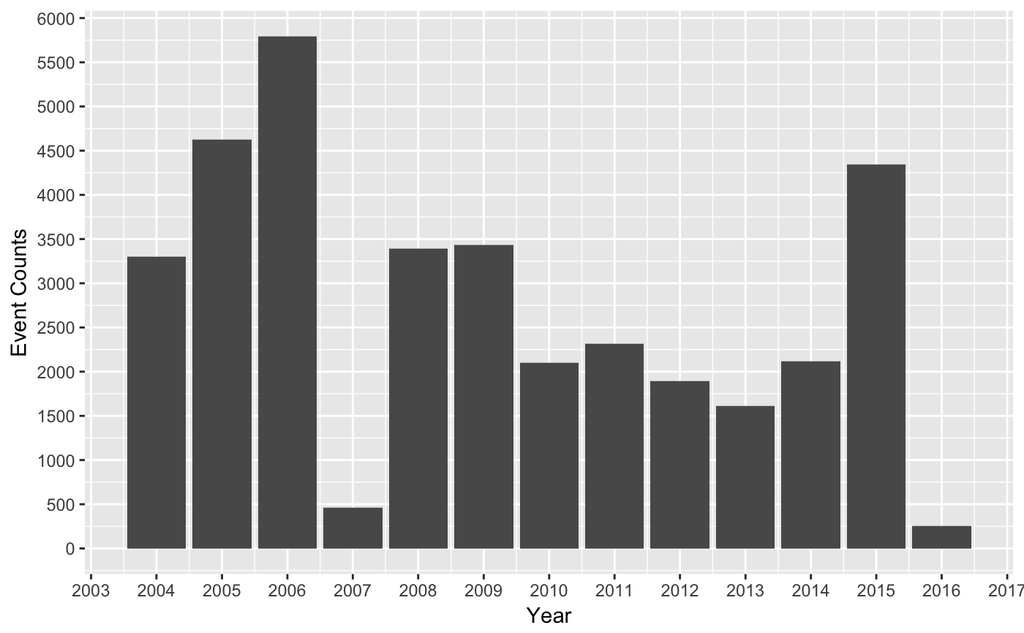

```r
bardata <- events %>%
  mutate(year_time = as_date(floor_date(time, "year"))) %>%
  group_by(year_time) %>%
  summarize(freq = sum(freq))
  ggplot(bardata) +
      geom_bar(aes(x=year_time, y=freq), stat="identity") +
      scale_y_continuous(breaks=seq(0,6000, 500)) +
      scale_x_date(date_breaks="1 year", date_labels="%Y") +
      labs(x="Year", y="Event Counts")
```

### 2.2 Distribution of Event Categories

One can see the distrubtion of event categories:

```r
events %>% count(category)
```

| category | n |
| --- | --- |
| 0 | 4157 |
| 1 | 26675 |
| 2 | 226 |
| 3 | 3527 |
| 4 | 796 |
| 5 | 268 |

While in `events` each row is an event, I want each row to be a particular date with information of the frequency of an event of a particular type on that date.

```r
event_sum <- events %>%
  group_by(time,direction,category) %>%
  summarize(freq = sum(freq)) %>%
  complete(time, direction, category, fill=list(freq=0))
event_sum %>% head()
```

| time | direction | category | freq |
| --- | --- | --- | --- |
| 2004-01-01 | K2J | 0 | 0 |
| 2004-01-01 | K2J | 1 | 0 |
| 2004-01-01 | K2J | 2 | 0 |
| 2004-01-01 | K2J | 3 | 13 |
| 2004-01-01 | K2J | 4 | 0 |
| 2004-01-01 | K2J | 5 | 0 |

### 2.3 Daily Data

Now I have made each event category into its own coloumn and the data is ready for Time Series analysis.

```r
event_transposed <- event_sum %>%
  spread(key = "category", value = "freq")
names(event_transposed)[3:7] <- c("neutral", "ver_coop", "mat_coop", "ver_conf", "mat_conf")
event_transposed %>% head() %>% knitr::kable()
```

| time | direction | neutral | ver_coop | mat_coop | ver_conf | mat_conf | 5 |
| --- | --- | --- | --- | --- | --- | --- | --- |
| 2004-01-01 | K2J | 0 | 0 | 0 | 13 | 0 | 0 |
| 2004-01-02 | J2K | 0 | 21 | 0 | 0 | 0 | 0 |
| 2004-01-02 | K2J | 2 | 21 | 0 | 21 | 0 | 0 |
| 2004-01-03 | J2K | 2 | 1 | 0 | 0 | 0 | 0 |
| 2004-01-03 | K2J | 3 | 1 | 0 | 3 | 0 | 0 |
| 2004-01-04 | J2K | 0 | 1 | 0 | 0 | 0 | 0 |

#### 2.3.1 Summary Statistics

```r
summary(event_transposed)
```

```
      time                      direction            neutral           ver_coop
 Min.   :2004-01-01 00:00:00   Length:5304        Min.   : 0.0000   Min.   :  0.000
 1st Qu.:2006-06-04 18:00:00   Class :character   1st Qu.: 0.0000   1st Qu.:  1.000
 Median :2009-11-04 00:00:00   Mode  :character   Median : 0.0000   Median :  2.000
 Mean   :2009-12-14 08:38:16                      Mean   : 0.7837   Mean   :  5.029
 3rd Qu.:2013-04-21 00:00:00                      3rd Qu.: 1.0000   3rd Qu.:  5.000
 Max.   :2016-01-31 00:00:00                      Max.   :23.0000   Max.   :138.000
    mat_coop           ver_conf         mat_conf             5
 Min.   : 0.00000   Min.   : 0.000   Min.   : 0.0000   Min.   : 0.00000
 1st Qu.: 0.00000   1st Qu.: 0.000   1st Qu.: 0.0000   1st Qu.: 0.00000
 Median : 0.00000   Median : 0.000   Median : 0.0000   Median : 0.00000
 Mean   : 0.04261   Mean   : 0.665   Mean   : 0.1501   Mean   : 0.05053
 3rd Qu.: 0.00000   3rd Qu.: 0.000   3rd Qu.: 0.0000   3rd Qu.: 0.00000
 Max.   :12.00000   Max.   :47.000   Max.   :22.0000   Max.   :12.00000
```

#### 2.3.2 Time Series Across Categories (Daily)

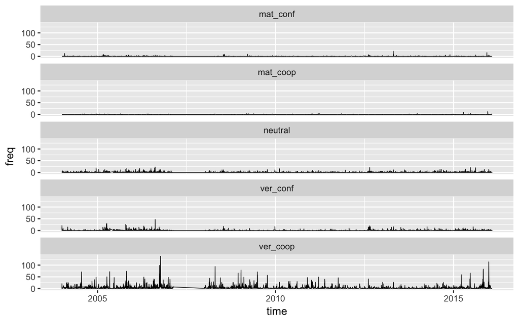

```r
event_transposed %>% gather(neutral:mat_conf, key="event", value="freq") %>%
  ggplot(aes(x=time, y=freq)) + geom_line(size=0.3) + facet_wrap(~event, ncol=1)
```

#### 2.3.3 The “First Difference” of Time Series Across Categories (Daily)

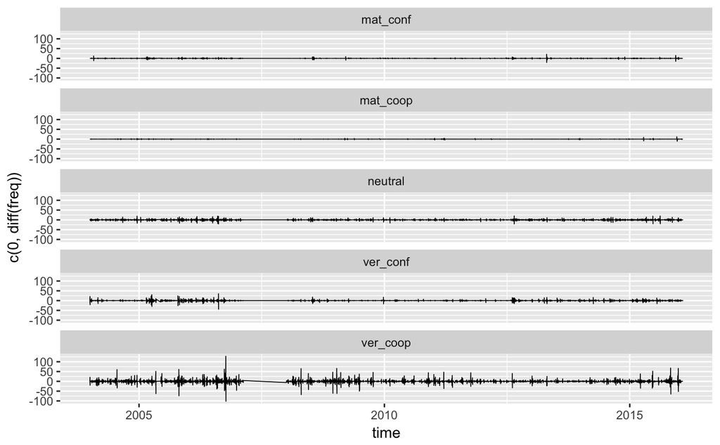

```r
event_transposed %>% gather(neutral:mat_conf, key="event", value="freq") %>%
  ggplot(aes(x=time, y=c(0,diff(freq)))) + geom_line(size=0.3) + facet_wrap(~event, ncol=1)
```

### 2.4 Weekly Data

#### 2.4.1 Data Structure

```r
event_transposed_weekly <-
  event_transposed %>%
  mutate(time_week = floor_date(time, "week")) %>%
  group_by(time_week) %>% # I take out direction so it becomes dyadic
  summarize(
    neutral = sum(neutral),
    ver_coop = sum(ver_coop),
    mat_coop = sum(mat_coop),
    ver_conf = sum(ver_conf),
    mat_conf = sum(mat_conf)
  )
event_transposed_weekly %>% head()
```

| time_week | neutral | ver_coop | mat_coop | ver_conf | mat_conf |
| --- | --- | --- | --- | --- | --- |
| 2003-12-28 | 7 | 44 | 0 | 37 | 0 |
| 2004-01-04 | 12 | 18 | 0 | 11 | 0 |
| 2004-01-11 | 15 | 57 | 1 | 17 | 4 |
| 2004-01-18 | 8 | 47 | 0 | 3 | 0 |
| 2004-01-25 | 4 | 30 | 0 | 2 | 13 |
| 2004-02-01 | 6 | 18 | 0 | 1 | 2 |

#### 2.4.2 Time Series Across Categories (Weekly)

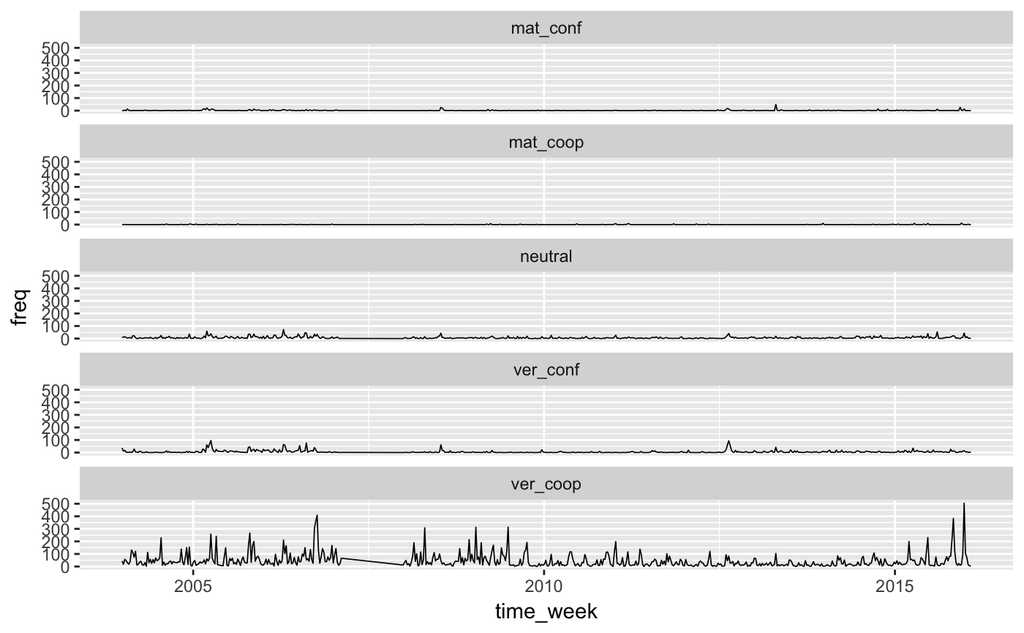

```r
event_transposed_weekly %>% gather(neutral:mat_conf, key="event", value="freq") %>%
  ggplot(aes(x=time_week, y=freq)) + geom_line(size=0.3) + facet_wrap(~event, ncol=1) +
  scale_y_continuous()
```

#### 2.4.3 Summary Statistics

```r
summary(event_transposed_weekly)
```

```
   time_week                      neutral         ver_coop         mat_coop
 Min.   :2003-12-28 00:00:00   Min.   : 0.00   Min.   :  0.00   Min.   : 0.0000
 1st Qu.:2006-10-25 12:00:00   1st Qu.: 2.00   1st Qu.: 11.50   1st Qu.: 0.0000
 Median :2010-06-13 00:00:00   Median : 4.00   Median : 26.00   Median : 0.0000
 Mean   :2010-03-23 14:05:35   Mean   : 7.18   Mean   : 46.07   Mean   : 0.3903
 3rd Qu.:2013-04-10 12:00:00   3rd Qu.: 9.50   3rd Qu.: 56.00   3rd Qu.: 0.0000
 Max.   :2016-01-31 00:00:00   Max.   :72.00   Max.   :504.00   Max.   :12.0000
    ver_conf         mat_conf
 Min.   : 0.000   Min.   : 0.000
 1st Qu.: 0.000   1st Qu.: 0.000
 Median : 2.000   Median : 0.000
 Mean   : 6.092   Mean   : 1.375
 3rd Qu.: 7.000   3rd Qu.: 1.000
 Max.   :96.000   Max.   :49.000
```

#### 2.4.3 Hiding Verbal Cooperation

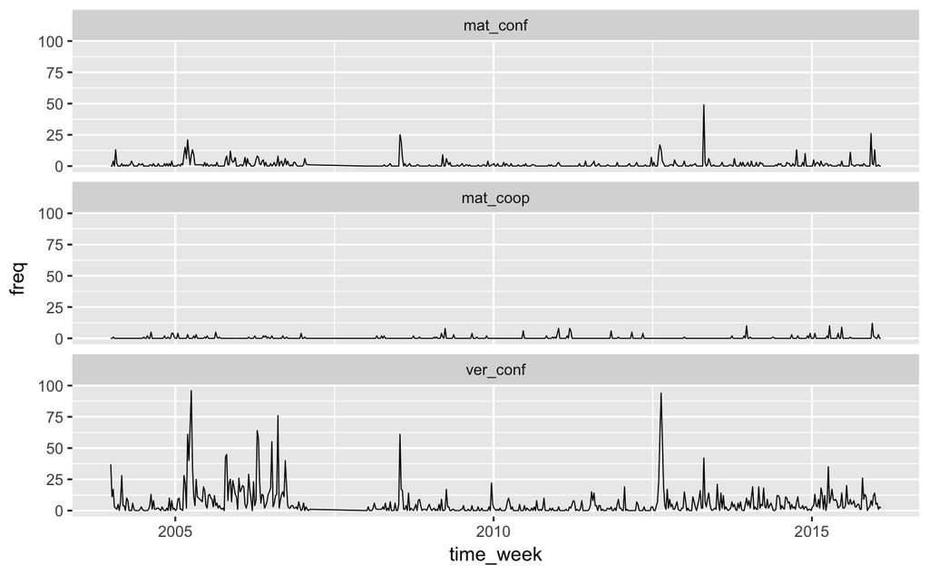

```r
event_transposed_weekly %>%
  select(-ver_coop, -neutral) %>%
  gather(mat_coop:mat_conf, key="event", value="freq") %>%
  ggplot(aes(x=time_week, y=freq)) + geom_line(size=0.3) + facet_wrap(~event, ncol=1) +
  scale_y_continuous()
```

## 3. Time Series Modeling

### 3.1 Setup

#### 3.1.1 Packages

```r
library(tseries)
library(tsDyn)
library(urca)
```

#### 3.1.2 Selecting Time Frame (2007 has issue) + Directionality (No-direction)

```r
ritualized_day <- event_transposed %>%
  group_by(time) %>%
  summarize(
    neutral = sum(neutral),
    ver_coop = sum(ver_coop),
    mat_coop = sum(mat_coop),
    ver_conf = sum(ver_conf),
    mat_conf = sum(mat_conf)
  ) %>%
  filter(time > as_date("2008-01-01"))
```

### 3.2 Testing Stationarity with Augmented Dickey-Fuller Test

#### 3.2.1 Verbal Conflict (Stationery)

```r
ur.df(ritualized_day$ver_conf, type = "trend", lags = 20, selectlags="AIC") %>%
  summary()
```

```
###############################################
# Augmented Dickey-Fuller Test Unit Root Test #
###############################################

Test regression trend


Call:
lm(formula = z.diff ~ z.lag.1 + 1 + tt + z.diff.lag)

Residuals:
    Min      1Q  Median      3Q     Max
-5.8021 -0.7344 -0.3334 -0.0649 30.8340

Coefficients:
              Estimate Std. Error t value Pr(>|t|)
(Intercept)  1.561e-01  9.475e-02   1.647   0.0997 .
z.lag.1     -3.493e-01  3.452e-02 -10.120  < 2e-16 ***
tt           1.549e-04  8.151e-05   1.901   0.0574 .
z.diff.lag1 -3.866e-01  3.687e-02 -10.486  < 2e-16 ***
z.diff.lag2 -2.576e-01  3.643e-02  -7.071 2.13e-12 ***
z.diff.lag3 -2.451e-01  3.497e-02  -7.008 3.30e-12 ***
z.diff.lag4 -2.126e-01  3.308e-02  -6.427 1.63e-10 ***
z.diff.lag5 -1.742e-01  3.065e-02  -5.684 1.51e-08 ***
z.diff.lag6 -1.126e-01  2.773e-02  -4.060 5.11e-05 ***
z.diff.lag7  4.922e-02  2.241e-02   2.196   0.0282 *
---
Signif. codes:  0 ‘***’ 0.001 ‘**’ 0.01 ‘*’ 0.05 ‘.’ 0.1 ‘ ’ 1

Residual standard error: 2.06 on 1987 degrees of freedom
Multiple R-squared:  0.3721,    Adjusted R-squared:  0.3692
F-statistic: 130.8 on 9 and 1987 DF,  p-value: < 2.2e-16


Value of test-statistic is: -10.1203 34.1419 51.2124

Critical values for test statistics:
      1pct  5pct 10pct
tau3 -3.96 -3.41 -3.12
phi2  6.09  4.68  4.03
phi3  8.27  6.25  5.34
```

#### 3.2.1 Verbal Cooperation (Stationery)

```r
ur.df(ritualized_day$ver_coop, type = "trend", lags = 30, selectlags="AIC") %>%
  summary()
```

```
###############################################
# Augmented Dickey-Fuller Test Unit Root Test #
###############################################

Test regression trend


Call:
lm(formula = z.diff ~ z.lag.1 + 1 + tt + z.diff.lag)

Residuals:
    Min      1Q  Median      3Q     Max
-51.875  -5.169  -3.145   1.053 176.811

Coefficients:
              Estimate Std. Error t value Pr(>|t|)
(Intercept)  5.2013014  0.7080758   7.346 2.98e-13 ***
z.lag.1     -0.5180102  0.0298710 -17.342  < 2e-16 ***
tt          -0.0009523  0.0005498  -1.732  0.08338 .
z.diff.lag1 -0.0471567  0.0289769  -1.627  0.10381
z.diff.lag2 -0.0790278  0.0257066  -3.074  0.00214 **
z.diff.lag3 -0.0622237  0.0224213  -2.775  0.00557 **
---
Signif. codes:  0 ‘***’ 0.001 ‘**’ 0.01 ‘*’ 0.05 ‘.’ 0.1 ‘ ’ 1

Residual standard error: 13.99 on 1981 degrees of freedom
Multiple R-squared:  0.2891,    Adjusted R-squared:  0.2873
F-statistic: 161.1 on 5 and 1981 DF,  p-value: < 2.2e-16


Value of test-statistic is: -17.3416 100.2446 150.367

Critical values for test statistics:
      1pct  5pct 10pct
tau3 -3.96 -3.41 -3.12
phi2  6.09  4.68  4.03
phi3  8.27  6.25  5.34
```

```r
ur.df(ritualized_day$mat_coop, type = "trend", lags = 30, selectlags="AIC") %>%
  summary()
```

```
###############################################
# Augmented Dickey-Fuller Test Unit Root Test #
###############################################

Test regression trend


Call:
lm(formula = z.diff ~ z.lag.1 + 1 + tt + z.diff.lag)

Residuals:
    Min      1Q  Median      3Q     Max
-0.8700 -0.0837 -0.0712 -0.0577 11.9080

Coefficients:
              Estimate Std. Error t value Pr(>|t|)
(Intercept)  4.497e-02  2.718e-02   1.654  0.09823 .
z.lag.1     -8.399e-01  4.198e-02 -20.005  < 2e-16 ***
tt           2.378e-05  2.311e-05   1.029  0.30364
z.diff.lag1 -1.005e-01  3.699e-02  -2.718  0.00663 **
z.diff.lag2 -8.007e-02  3.076e-02  -2.603  0.00931 **
z.diff.lag3 -5.802e-02  2.243e-02  -2.587  0.00976 **
---
Signif. codes:  0 ‘***’ 0.001 ‘**’ 0.01 ‘*’ 0.05 ‘.’ 0.1 ‘ ’ 1

Residual standard error: 0.5902 on 1981 degrees of freedom
Multiple R-squared:  0.4709,    Adjusted R-squared:  0.4695
F-statistic: 352.6 on 5 and 1981 DF,  p-value: < 2.2e-16


Value of test-statistic is: -20.005 133.4 200.1

Critical values for test statistics:
      1pct  5pct 10pct
tau3 -3.96 -3.41 -3.12
phi2  6.09  4.68  4.03
phi3  8.27  6.25  5.34
```

#### 3.2.4 Material Cooperation (Stationery)

```r
ur.df(ritualized_day$mat_coop, type = "trend", lags = 30, selectlags="AIC") %>%
  summary()
```

```
###############################################
# Augmented Dickey-Fuller Test Unit Root Test #
###############################################

Test regression trend


Call:
lm(formula = z.diff ~ z.lag.1 + 1 + tt + z.diff.lag)

Residuals:
    Min      1Q  Median      3Q     Max
-0.8700 -0.0837 -0.0712 -0.0577 11.9080

Coefficients:
              Estimate Std. Error t value Pr(>|t|)
(Intercept)  4.497e-02  2.718e-02   1.654  0.09823 .
z.lag.1     -8.399e-01  4.198e-02 -20.005  < 2e-16 ***
tt           2.378e-05  2.311e-05   1.029  0.30364
z.diff.lag1 -1.005e-01  3.699e-02  -2.718  0.00663 **
z.diff.lag2 -8.007e-02  3.076e-02  -2.603  0.00931 **
z.diff.lag3 -5.802e-02  2.243e-02  -2.587  0.00976 **
---
Signif. codes:  0 ‘***’ 0.001 ‘**’ 0.01 ‘*’ 0.05 ‘.’ 0.1 ‘ ’ 1

Residual standard error: 0.5902 on 1981 degrees of freedom
Multiple R-squared:  0.4709,    Adjusted R-squared:  0.4695
F-statistic: 352.6 on 5 and 1981 DF,  p-value: < 2.2e-16


Value of test-statistic is: -20.005 133.4 200.1

Critical values for test statistics:
      1pct  5pct 10pct
tau3 -3.96 -3.41 -3.12
phi2  6.09  4.68  4.03
phi3  8.27  6.25  5.34
```

### 3.3 Specifying AutoRegression & Moving Average (ARMA)

#### 3.3.1 Verbal Conflict (ARMA 1,7?)

##### 3.3.1.1 ACF

```r
par(mfrow=c(2,2))
acf(ritualized_day$ver_conf)
acf(diff(ritualized_day$ver_conf, 7))
```

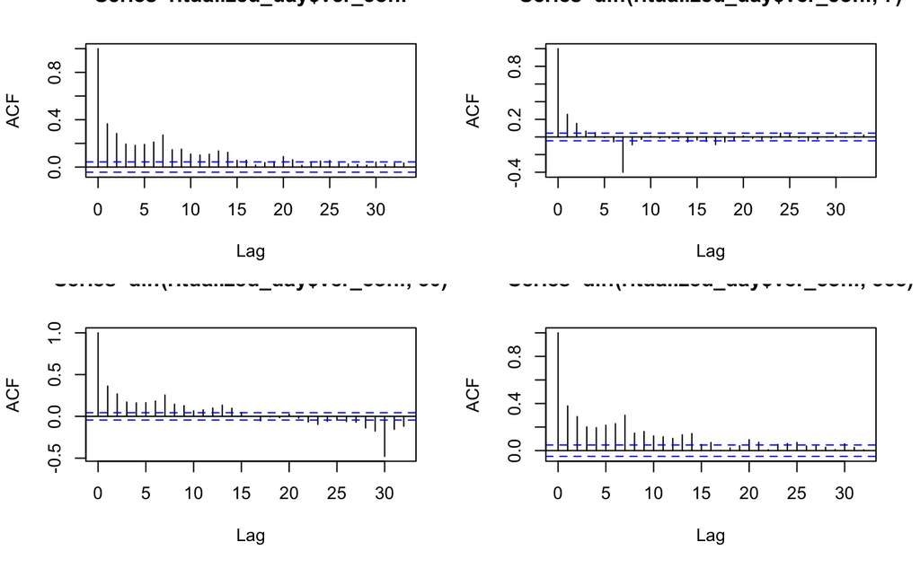

```r
acf(diff(ritualized_day$ver_conf, 30))
acf(diff(ritualized_day$ver_conf, 365))
```

##### 3.3.1.1 PACF

```r
par(mfrow=c(2,2))
pacf(ritualized_day$ver_conf)
pacf(diff(ritualized_day$ver_conf, 7))
```

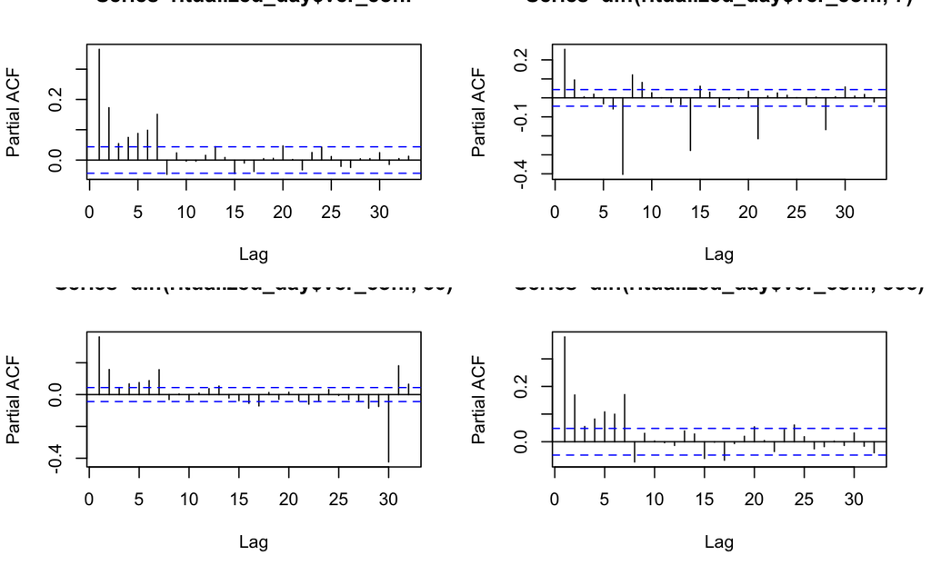

```r
pacf(diff(ritualized_day$ver_conf, 30))
pacf(diff(ritualized_day$ver_conf, 365))
```

#### 3.3.2 Verbal Cooperation (ARMA 1)

##### 3.3.2.1 ACF

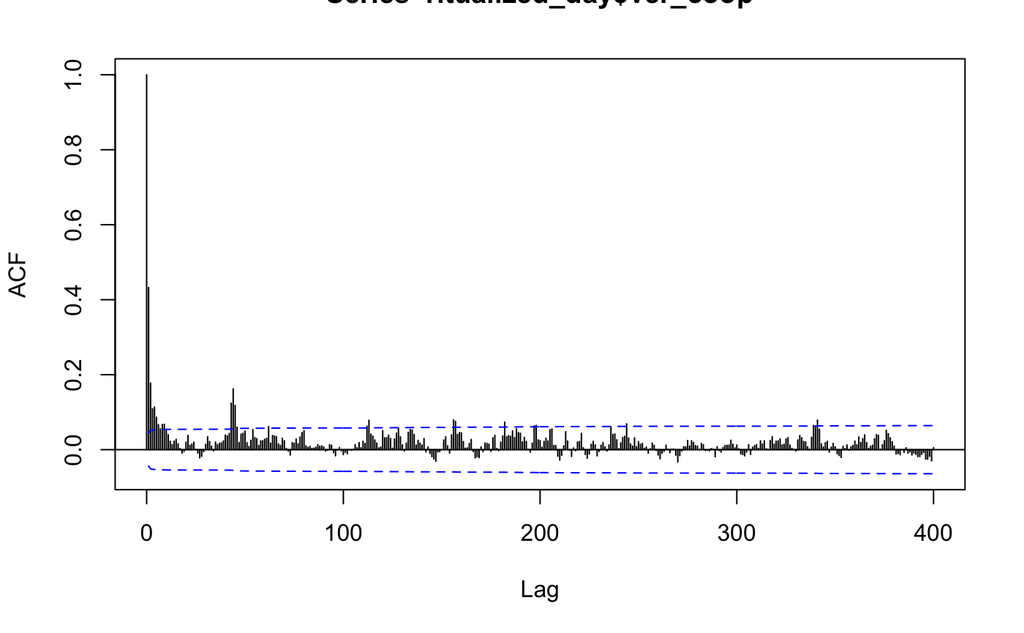

```r
acf(ritualized_day$ver_coop, lag.max=400, ci.type = "ma")
```

##### 3.3.2.1 PACF

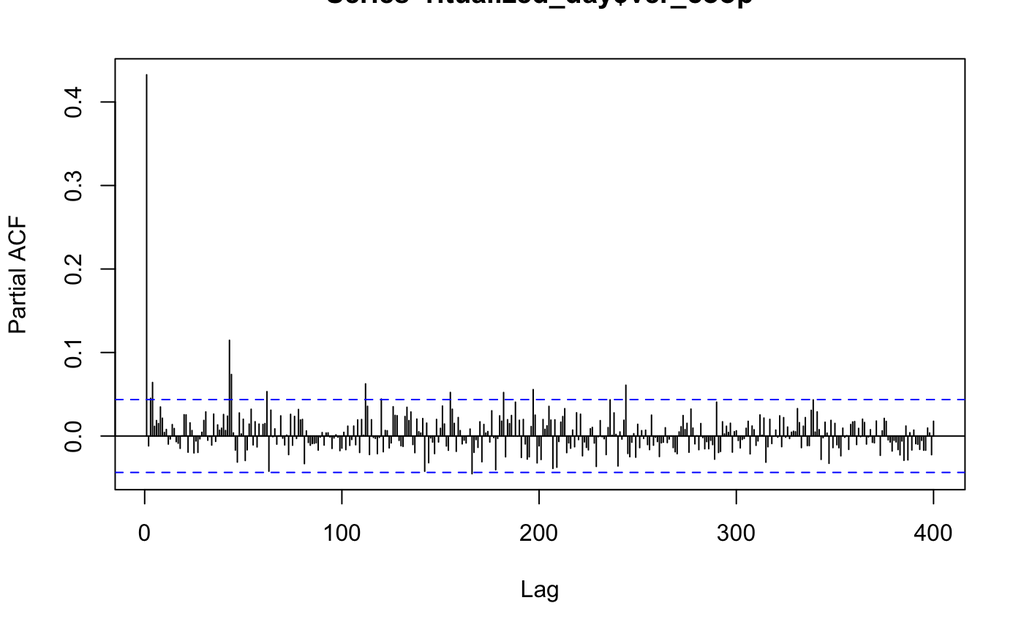

```r
pacf(ritualized_day$ver_coop, lag.max=400)
```

##### 3.3.2.1 ACF

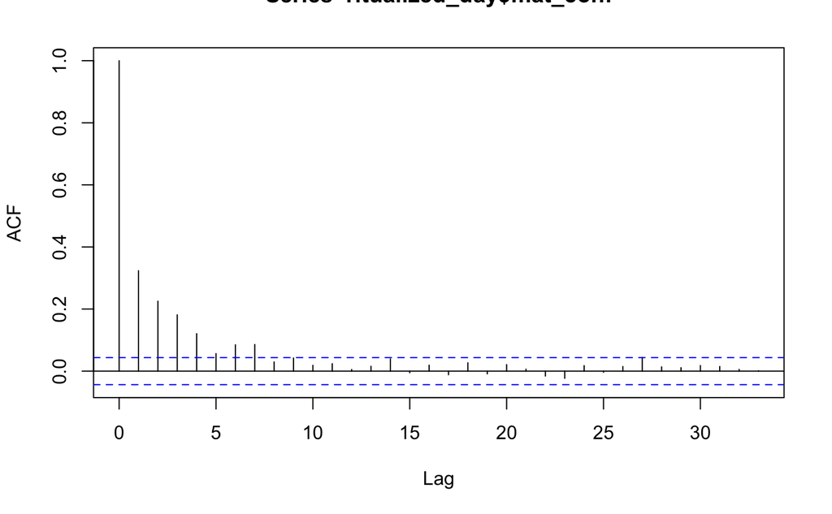

```r
acf(ritualized_day$mat_conf)
```

##### 3.3.2.1 PACF

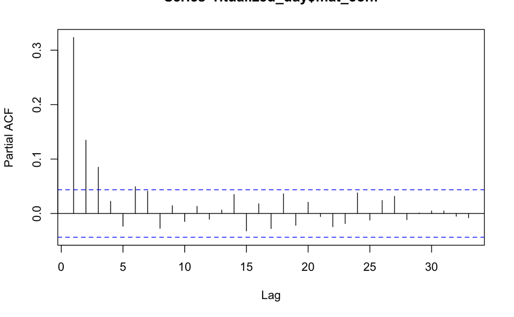

```r
pacf(ritualized_day$mat_conf)
```

#### 3.3.4 Material Cooperation (ARMA 1)

##### 3.3.4.1 ACF

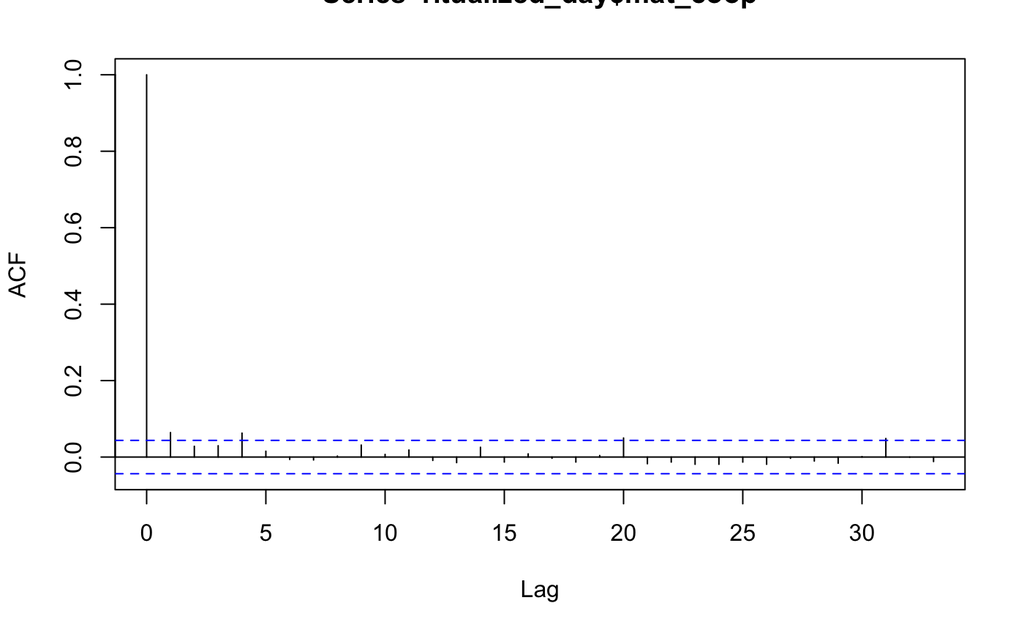

```r
acf(ritualized_day$mat_coop)
```

##### 3.3.4.1 PACF

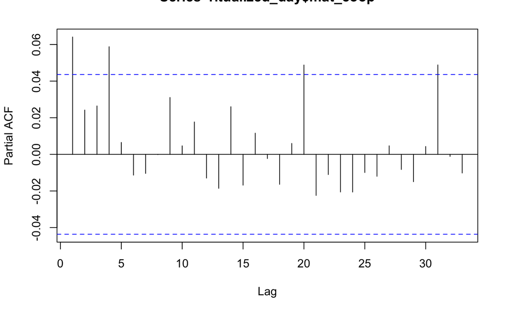

```r
pacf(ritualized_day$mat_coop)
```